# baseline_model

### In this notebook, I am cocatenate all meaningful data in one dataframe.

```python
import pandas as pd
import numpy as np
from util import *
import warnings
warnings.filterwarnings("ignore")
```

```python
import os

datafolder = 'GPE7'
file_path = 'Dat/'+datafolder
files = os.listdir(file_path)
#files.remove('readme')
```

```python
files
```

```
['.DS_Store', 'C1538.xls', 'C1532.xls', 'C1526.xls', 'C1535.xls', 'C1536.xls']
```

ocv_charging.head(5)

col =['Cycle ID', 'Step Name', 'Voltage(V)', 'Current(mA)', 'Capacity(mAh)', 'Time(h:min:s.ms)', 'Realtime', 'Time', 'RTime']

# opening the file in read mode

my_file = open("cells.txt", "r")

# reading the file

data = my_file.read()

# replacing end of line('/n') with ' ' and

# splitting the text it further when '.' is seen.

cells_into_list = data.split("\n")

## Define functions to read files with selected columns, convert data from a column data to row data.

```python
#get data from dataframe for interested columns
def get_df(path='ProcessedData/'+datafolder+'/',fileName = 'OCV-charge-final.csv', interestCol='Voltage(V)'):


    df = read_file(path+fileName)
    if type(interestCol) == list:
        new = df[interestCol]

    else:
        new = df[[interestCol]]
    return new

#convert data from columns to rows, reset index with cellID
def convertData(df, index_col = 'CellID'):
    ndf = df.unstack().to_frame().T
    ndf.columns = ndf.columns.map('{0[0]}_{0[1]}'.format)
    ndf['CellID'] = index_col
    ndf.set_index(['CellID'],inplace=True)

    return ndf
```

## Define selected columns name, change the name according to the cell name

```python
path='ProcessedData/'+datafolder+'/'
# original columns name
col =['Cycle ID', 'Step Name', 'Voltage(V)',
       'Current(mA)', 'Capacity(mAh)', 'Time(h:min:s.ms)',
       'Realtime', 'Time', 'RTime']
col2 =['Cycle ID', 'Step Name', 'Voltage(V)-d',
       'Current(mA)', 'Capacity(mAh)', 'Time(h:min:s.ms)',
       'Realtime', 'Time', 'RTime']
cap_col=['Cycle ID', 'Cap_Chg(mAh)',
       'Cap_DChg(mAh)', 'Chg/DChg Efficiency(%)']

#set the number correctly depending the ending condition
cyc_dis = 74 # define how many cycles in the datasheet, length of data
cyc_charging = 75 #define voltage data
#rename columns' name for all data frame
all_list = ['OCV_charge', 'OCV_discharge', 'Cap_new','Vol_new']

OCV_charge = ['OCV_charge'+str(c) for c in range(1,cyc_charging+1)]

OCV_discharge = ['OCV_discharge'+str(c) for c in range(1,cyc_dis+1)]

drop_cycid = ['Cycle ID'+str(c) for c in range(1,cyc_charging+1) ]
Cap_new = []
Vol_new = []
voltage_max = []
voltage_min = []
cyc = []

for i, j in zip(col, cap_col):
    for l in range(1,cyc_charging+1):

        Vol_new.append(i+str(l))
        Cap_new.append(j+str(l))

for l in range(1,cyc_charging+1):

    voltage_max.append('Voltage_max'+str(l))

    voltage_min.append('Voltage_min'+str(l))
    cyc.append('Cycle ID'+str(l))
```

```python
print(len(cyc), len(Vol_new))
```

```
75 300
```

```python
#c = df_final.columns.to_list()
#c[0].startswith('Cyc')
Col_cap = [c+"C1526" for c in cap_col]
cell_cap = get_df(path, 'Cap_final.csv', interestCol=Col_cap)
cell_cap.head()
```

|  | Cycle IDC1526 | Cap_Chg(mAh)C1526 | Cap_DChg(mAh)C1526 | Chg/DChg Efficiency(%)C1526 |
| --- | --- | --- | --- | --- |
| 0 | 1.0 | 3.5001 | 3.1974 | 91.352 |
| 1 | 2.0 | 3.2762 | 3.2799 | 100.113 |
| 2 | 3.0 | 3.2909 | 3.3607 | 102.120 |
| 3 | 4.0 | 3.3658 | 3.3276 | 98.864 |
| 4 | 5.0 | 3.3224 | 3.2781 | 98.667 |

```python
cell_cap.tail()
```

|  | Cycle IDC1526 | Cap_Chg(mAh)C1526 | Cap_DChg(mAh)C1526 | Chg/DChg Efficiency(%)C1526 |
| --- | --- | --- | --- | --- |
| 70 | 71.0 | 3.2330 | 3.3079 | 102.315 |
| 71 | 72.0 | 3.3123 | 3.2176 | 97.141 |
| 72 | 73.0 | 3.2164 | 3.2149 | 99.951 |
| 73 | 74.0 | 3.2158 | 0.6326 | 19.671 |
| 74 | NaN | NaN | NaN | NaN |

```python
cell_cap['Cap_retention'] = cell_cap['Cap_DChg(mAh)C1526']/cell_cap.iloc[0]['Cap_Chg(mAh)C1526']
```

```python
cell_cap.tail()
```

|  | Cycle IDC1526 | Cap_Chg(mAh)C1526 | Cap_DChg(mAh)C1526 | Chg/DChg Efficiency(%)C1526 | Cap_retention |
| --- | --- | --- | --- | --- | --- |
| 70 | 71.0 | 3.2330 | 3.3079 | 102.315 | 0.945087 |
| 71 | 72.0 | 3.3123 | 3.2176 | 97.141 | 0.919288 |
| 72 | 73.0 | 3.2164 | 3.2149 | 99.951 | 0.918517 |
| 73 | 74.0 | 3.2158 | 0.6326 | 19.671 | 0.180738 |
| 74 | NaN | NaN | NaN | NaN | NaN |

```python
p = convertData(cell_cap,index_col= "C1526")
```

```python
p.head()
```

| CellID | Cycle IDC1526_0 | Cycle IDC1526_1 | Cycle IDC1526_2 | Cycle IDC1526_3 | Cycle IDC1526_4 | Cycle IDC1526_5 | Cycle IDC1526_6 | Cycle IDC1526_7 | Cycle IDC1526_8 | Cycle IDC1526_9 | ... | Cap_retention_65 | Cap_retention_66 | Cap_retention_67 | Cap_retention_68 | Cap_retention_69 | Cap_retention_70 | Cap_retention_71 | Cap_retention_72 | Cap_retention_73 | Cap_retention_74 |
| --- | --- | --- | --- | --- | --- | --- | --- | --- | --- | --- | --- | --- | --- | --- | --- | --- | --- | --- | --- | --- | --- |
| C1526 | 1.0 | 2.0 | 3.0 | 4.0 | 5.0 | 6.0 | 7.0 | 8.0 | 9.0 | 10.0 | ... | 0.917974 | 0.928973 | 0.915117 | 0.916917 | 0.923231 | 0.945087 | 0.919288 | 0.918517 | 0.180738 | NaN |

1 rows × 375 columns

```python
p.shape
```

```
(1, 375)
```

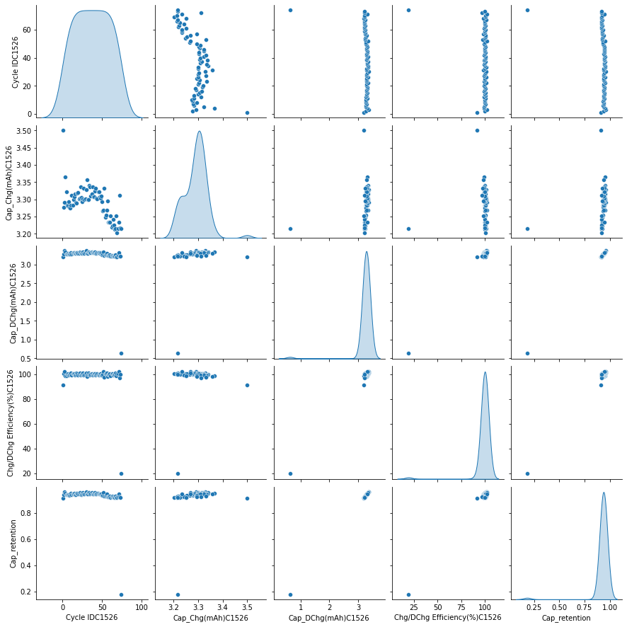

```python
import seaborn as sns
sns.pairplot(cell_cap[cell_cap.columns], diag_kind='kde')
```

## Experiment regression on single cell data to predict capacity retention.

Use linear regression first

```python
#!pip install tensorflow
```

```python
#!pip install keras
```

```python
from sklearn.pipeline import Pipeline
from sklearn.model_selection import train_test_split
from sklearn.metrics import mean_squared_error, r2_score
from sklearn.preprocessing import StandardScaler
#from keras.wrappers.scikit_learn import KerasClassifier
from keras.wrappers.scikit_learn import KerasRegressor
def create_model(learning_rate=0.01):
    linear_model = tf.keras.Sequential([normalizer, tf.keras.layers.Dense(1)])
    linear_model.compile(optimizer=tf.keras.optimizers.Adam(learning_rate=learning_rate), loss='MAE',metrics=['accuracy'])

    return linear_model

clf = KerasRegressor(build_fn=create_model, epochs=100, verbose=0, validation_split = 0.2)

def tf_train(X, y, clf,standardize = True) -> None:
    X_train, X_test, y_train, y_test = train_test_split(X,y,test_size=0.2, random_state=0)
    print(X_train.shape, y_train.shape)

    if standardize:
        #pipeline = Pipeline([('clf',clf)])
        pipe = Pipeline([('scaler',StandardScaler()), ('classifier',clf)])
        print("Using Normalized data")
    else:
        pipe = Pipeline(['classifier',clf])


    history = pipe.fit(X_train, y_train)

    y_pred = pipe.predict(X_test)

    print("Mean squared error ",mean_squared_error(y_test, y_pred))
    print("r2 score ",r2_score(y_test, y_pred))
    return y_pred
```

## Convert data for all cells, export data to one dataframe for clustering

Need to predefine the 'cells.txt' file

```python
# opening the file in read mode
my_file = open(path+datafolder+"cells.txt", "r")

# reading the file
data = my_file.read()

# replacing end of line('/n') with ' ' and
# splitting the text it further when '.' is seen.
cells_into_list = data.split("\n")
cells_into_list.pop()
ocv_1 = pd.DataFrame()
ocv_2 = pd.DataFrame()
Cap = pd.DataFrame()
df_max = pd.DataFrame()
df_min = pd.DataFrame()
for cell in cells_into_list:
    print("processing cells: ", cell)
    Col = 'Voltage(V)' + cell
    Col_cap = [c+cell for c in cap_col]

    df = get_df(path, 'OCV-charge-final.csv', interestCol=Col)
    ndf = convertData(df,index_col=cell)
    #change column name according to cycle numbers
    print("Coverting charging OCV...")
    ndf.columns=OCV_charge

    ocv_1 = pd.concat([ocv_1,ndf], axis=0)

    df2 = get_df(path, 'OCV-discharge-final.csv', interestCol=Col)
    print("Coverting discharging OCV ...")
    ndf2 = convertData(df2,index_col=cell)
    ndf2.columns=OCV_discharge
    ocv_2 = pd.concat([ocv_2,ndf2], axis=0)

    cell_cap = get_df(path, 'Cap_final.csv', interestCol=Col_cap)
    cell_cap['Cap_retention'] = cell_cap['Cap_DChg(mAh)'+cell]/cell_cap.iloc[0]['Cap_Chg(mAh)'+cell]
    p = convertData(cell_cap,index_col= cell)
    p.columns = Cap_new

    Cap = pd.concat([Cap,p], axis=0)

    #find out the max and minimum potential during charging discharging
    vol = pd.read_csv(path+ 'Vol_final.csv')
    max_v = pd.DataFrame(vol.groupby('Cycle ID'+cell)[Col].max())
    min_v = pd.DataFrame(vol.groupby('Cycle ID'+cell)[Col].min())
    print("max_v, min_v shape",max_v.shape, min_v.shape)
    #convert data to one row
    print("Coverting max charging OCV...")
    df_max_v = convertData(max_v,index_col=cell)
    df_max_v.columns=voltage_max[:df_max_v.shape[1]] #different length cycling

    print("Coverting min discharging OCV...")
    df_min_v = convertData(min_v,index_col=cell)
    df_min_v.columns=voltage_min[:df_min_v.shape[1]]

    df_max = pd.concat([df_max,df_max_v],axis=0)
    df_min = pd.concat([df_min,df_min_v],axis=0)

#concat all dataframe into one
df_final = pd.concat([ocv_1,
ocv_2,
Cap,
df_max,
df_min], axis = 1)
print("All data processing is done!")
```

## Convert data in one dataframe for one cell, selected features ocv, capacity for regression,

### Since all cells have the similar properties, we will concat all data together with the same column name.

```python
# This cell converts data with individual cell name
re = [] # retention
cy = [] # cycle ID
vo = [] # charge voltage
vo_d = [] # discharge voltage
# opening the file in read mode
my_file = open(path+datafolder+"cells.txt", "r")

# reading the file
data = my_file.read()

# replacing end of line('/n') with ' ' and
# splitting the text it further when '.' is seen.
cells_into_list = data.split("\n")
cells_into_list.pop()
ocv_1 = pd.DataFrame()
ocv_2 = pd.DataFrame()
Cap = pd.DataFrame()
df_max = pd.DataFrame()
df_min = pd.DataFrame()
for cell in cells_into_list:
    cy.append('Cycle ID'+cell)
    vo.append('Voltage(V)'+cell)
    vo_d.append('Voltage(V)-d'+cell)
    print("processing cells: ", cell)
    Col = 'Voltage(V)' + cell
    Col2 = 'Voltage(V)-d' + cell
    Col_cap = [c+cell for c in cap_col]

    df = get_df(path, 'OCV-charge-final.csv', interestCol=Col)
    print("Coverting charging OCV...")

    ocv_1 = pd.concat([ocv_1,df], axis=1)
    ocv_1 = ocv_1.loc[~ocv_1.index.duplicated(keep='first')]

    df2 = get_df(path, 'OCV-discharge-final.csv', interestCol=Col2)
    print("Coverting discharging OCV ...")


    ocv_2 = pd.concat([ocv_2,df2], axis=1)
    ocv_2 = ocv_2.loc[~ocv_2.index.duplicated(keep='first')]

    cell_cap = get_df(path, 'Cap_final.csv', interestCol=Col_cap)
    cell_cap['Cap_retention'+cell] = cell_cap['Cap_DChg(mAh)'+cell]/cell_cap.iloc[0]['Cap_Chg(mAh)'+cell]
    re.append('Cap_retention'+cell)
    Cap = pd.concat([Cap,cell_cap], axis=1)
    Cap = Cap.loc[~Cap.index.duplicated(keep='first')]


    #find out the max and minimum potential during charging discharging
    vol = pd.read_csv(path+ 'Vol_final.csv')
    max_v = pd.DataFrame(vol.groupby('Cycle ID'+cell)[Col].max())
    min_v = pd.DataFrame(vol.groupby('Cycle ID'+cell)[Col].min())
    print("max_v, min_v shape",max_v.shape, min_v.shape)
    #convert data to one row
    print("Coverting max charging OCV...")
    df_max = pd.concat([df_max,max_v],axis=1)
    df_max = df_max.loc[~df_max.index.duplicated(keep='first')]


    print("Coverting min discharging OCV...")

    df_min = pd.concat([df_min,min_v],axis=1)
    df_min = df_min.loc[~df_min.index.duplicated(keep='first')]



#concat all dataframe into one
df_final = pd.concat([ocv_1,
ocv_2,
Cap,
df_max,
df_min], axis = 1)
print("All data processing is done!")
```

```
processing cells:  C1538
Coverting charging OCV...
Coverting discharging OCV ...
max_v, min_v shape (75, 1) (75, 1)
Coverting max charging OCV...
Coverting min discharging OCV...
processing cells:  C1532
Coverting charging OCV...
Coverting discharging OCV ...
max_v, min_v shape (75, 1) (75, 1)
Coverting max charging OCV...
Coverting min discharging OCV...
processing cells:  C1526
Coverting charging OCV...
Coverting discharging OCV ...
max_v, min_v shape (74, 1) (74, 1)
Coverting max charging OCV...
Coverting min discharging OCV...
processing cells:  C1535
Coverting charging OCV...
Coverting discharging OCV ...
max_v, min_v shape (75, 1) (75, 1)
Coverting max charging OCV...
Coverting min discharging OCV...
processing cells:  C1536
Coverting charging OCV...
Coverting discharging OCV ...
max_v, min_v shape (74, 1) (74, 1)
Coverting max charging OCV...
Coverting min discharging OCV...
All data processing is done!
```

```python
# this cell convert all cells data in one .
re = [] # retention
cy = [] # cycle ID
vo = [] # charge voltage
vo_d = [] # discharge voltage
# opening the file in read mode
my_file = open(path+datafolder+"cells.txt", "r")

# reading the file
data = my_file.read()

# replacing end of line('/n') with ' ' and
# splitting the text it further when '.' is seen.
cells_into_list = data.split("\n")
cells_into_list.pop()
ocv_1 = pd.DataFrame()
ocv_2 = pd.DataFrame()
Cap = pd.DataFrame()
df_max = pd.DataFrame()
df_min = pd.DataFrame()
for cell in cells_into_list:
    cy.append('Cycle ID'+cell)
    vo.append('Voltage(V)'+cell)
    vo_d.append('Voltage(V)-d'+cell)
    print("processing cells: ", cell)
    Col = 'Voltage(V)' + cell
    Col2 = 'Voltage(V)-d' + cell
    Col_cap = [c+cell for c in cap_col]

    df = get_df(path, 'OCV-charge-final.csv', interestCol=Col)
    print("Coverting charging OCV...")

    df.columns = ['Voltage(V)']
    ocv_1 = pd.concat([ocv_1,df], axis=0,ignore_index=True)
    ocv_1 = ocv_1.loc[~ocv_1.index.duplicated(keep='first')]

    df2 = get_df(path, 'OCV-discharge-final.csv', interestCol=Col2)
    print("Coverting discharging OCV ...")

    df2.columns = ['Voltage(V)-d']
    ocv_2 = pd.concat([ocv_2,df2], axis=0,ignore_index=True)
    ocv_2 = ocv_2.loc[~ocv_2.index.duplicated(keep='first')]

    cell_cap = get_df(path, 'Cap_final.csv', interestCol=Col_cap)
    cell_cap['Cap_retention'+cell] = cell_cap['Cap_DChg(mAh)'+cell]/cell_cap.iloc[0]['Cap_Chg(mAh)'+cell]
    re.append('Cap_retention'+cell)
    cell_cap.columns = ['Cycle ID', 'Cap_Chg(mAh)', 'Cap_DChg(mAh)',
       'Chg/DChg Efficiency(%)', 'Cap_retention']
    Cap = pd.concat([Cap,cell_cap], axis=0,ignore_index=True)
    Cap = Cap.loc[~Cap.index.duplicated(keep='first')]


    #find out the max and minimum potential during charging discharging
    vol = pd.read_csv(path+ 'Vol_final.csv')
    max_v = pd.DataFrame(vol.groupby('Cycle ID'+cell)[Col].max())
    min_v = pd.DataFrame(vol.groupby('Cycle ID'+cell)[Col].min())
    print("max_v, min_v shape",max_v.shape, min_v.shape)
    #convert data to one row
    print("Coverting max charging OCV...")
    max_v.columns = ['Voltage(V)-max']
    df_max = pd.concat([df_max,max_v],axis=0,ignore_index=True)
    df_max = df_max.loc[~df_max.index.duplicated(keep='first')]


    print("Coverting min discharging OCV...")
    min_v.columns = ['Voltage(V)-min']
    df_min = pd.concat([df_min,min_v],axis=0,ignore_index=True)
    df_min = df_min.loc[~df_min.index.duplicated(keep='first')]



#concat all dataframe into one
df_final_one = pd.concat([ocv_1,
ocv_2,
Cap,
df_max,
df_min], axis = 1)
print("All data processing is done!")
```

```
processing cells:  C1538
Coverting charging OCV...
Coverting discharging OCV ...
max_v, min_v shape (75, 1) (75, 1)
Coverting max charging OCV...
Coverting min discharging OCV...
processing cells:  C1532
Coverting charging OCV...
Coverting discharging OCV ...
max_v, min_v shape (75, 1) (75, 1)
Coverting max charging OCV...
Coverting min discharging OCV...
processing cells:  C1526
Coverting charging OCV...
Coverting discharging OCV ...
max_v, min_v shape (74, 1) (74, 1)
Coverting max charging OCV...
Coverting min discharging OCV...
processing cells:  C1535
Coverting charging OCV...
Coverting discharging OCV ...
max_v, min_v shape (75, 1) (75, 1)
Coverting max charging OCV...
Coverting min discharging OCV...
processing cells:  C1536
Coverting charging OCV...
Coverting discharging OCV ...
max_v, min_v shape (74, 1) (74, 1)
Coverting max charging OCV...
Coverting min discharging OCV...
All data processing is done!
```

```python
df_final_one.columns
```

```
Index(['Voltage(V)', 'Voltage(V)-d', 'Cycle ID', 'Cap_Chg(mAh)',
       'Cap_DChg(mAh)', 'Chg/DChg Efficiency(%)', 'Cap_retention',
       'Voltage(V)-max', 'Voltage(V)-min'],
      dtype='object')
```

```python
df_min_v.head()
```

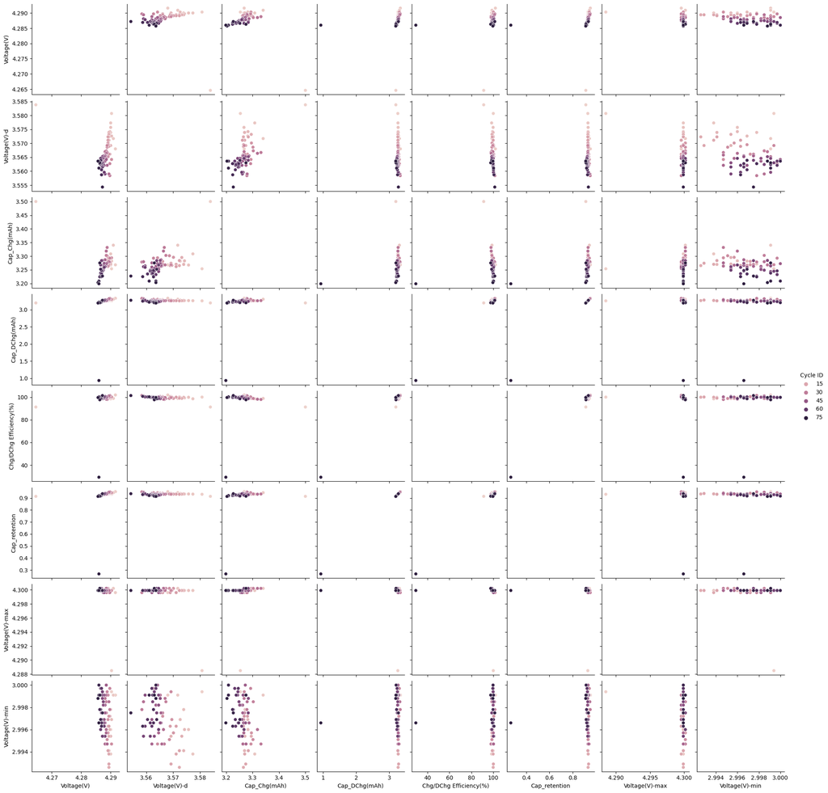

```python
sns.pairplot(df_final_one,hue='Cycle ID')
```

```python
df_final_one.tail()
```

|  | Voltage(V) | Voltage(V)-d | Cycle ID | Cap_Chg(mAh) | Cap_DChg(mAh) | Chg/DChg Efficiency(%) | Cap_retention | Voltage(V)-max | Voltage(V)-min |
| --- | --- | --- | --- | --- | --- | --- | --- | --- | --- |
| 71.0 | 4.2872 | 3.5543 | 72.0 | 3.2268 | 3.2752 | 101.501 | 0.935718 | 4.2999 | 2.9975 |
| 72.0 | 4.2863 | 3.5630 | 73.0 | 3.2749 | 3.2024 | 97.787 | 0.914919 | 4.3002 | 2.9991 |
| 73.0 | 4.2857 | 3.5636 | 74.0 | 3.2029 | 3.1951 | 99.754 | 0.912834 | 4.2999 | 2.9988 |
| 74.0 | 4.2860 | NaN | 75.0 | 3.1985 | 0.9346 | 29.220 | 0.267013 | 4.2999 | 2.9966 |
| 75.0 | NaN | NaN | NaN | NaN | NaN | NaN | NaN | 4.2999 | 3.5912 |

```python
df_final_one.shape
```

[output not shown]

```python
df_final_one.describe().T
```

|  | count | mean | std | min | 25% | 50% | 75% | max |
| --- | --- | --- | --- | --- | --- | --- | --- | --- |
| Voltage(V) | 365.0 | 4.284702 | 0.004368 | 4.250000 | 4.282900 | 4.2854 | 4.286900 | 4.291600 |
| Voltage(V)-d | 365.0 | 3.569271 | 0.006049 | 3.554300 | 3.564600 | 3.5689 | 3.573500 | 3.589400 |
| Cycle ID | 365.0 | 37.035616 | 21.160593 | 1.000000 | 19.000000 | 37.0000 | 55.000000 | 75.000000 |
| Cap_Chg(mAh) | 365.0 | 3.278646 | 0.044866 | 3.148100 | 3.254800 | 3.2801 | 3.299900 | 3.500200 |
| Cap_DChg(mAh) | 365.0 | 3.258836 | 0.188175 | 0.632600 | 3.251500 | 3.2753 | 3.297300 | 3.369800 |
| Chg/DChg Efficiency(%) | 365.0 | 99.398082 | 5.731816 | 19.671000 | 99.333000 | 100.0170 | 100.384000 | 102.714000 |
| Cap_retention | 365.0 | 0.931069 | 0.053763 | 0.180738 | 0.928973 | 0.9358 | 0.942086 | 0.962772 |
| Voltage(V)-max | 365.0 | 4.298298 | 0.033746 | 3.655700 | 4.299900 | 4.3002 | 4.300500 | 4.300900 |
| Voltage(V)-min | 365.0 | 3.002579 | 0.055184 | 2.992600 | 2.996300 | 2.9975 | 2.999100 | 3.619100 |

## use scikit learn for training

```python
from sklearn.pipeline import make_pipeline
from sklearn.model_selection import train_test_split
from sklearn import linear_model
from sklearn.metrics import mean_squared_error, r2_score


def train(X, y, standardize = True) -> None:
    X_train, X_test, y_train, y_test = train_test_split(X,y,test_size=0.2, random_state=0)


    if standardize:

        pipe = make_pipeline(StandardScaler(), linear_model.LinearRegression())
        print("Using Normalized data")
    else:
        pipe = make_pipeline(linear_model.LinearRegression())

    pipeline = pipe.fit(X_train,y_train)
    y_pred = pipeline.predict(X_test)

    print("Mean squared error ",mean_squared_error(y_test, y_pred))
    print("r2 score ",r2_score(y_test, y_pred))
    return y_pred
```

```python
#This training session has efficiency, voltage as X, retention is y.
# it should get a linear fitting well data since retention is linearly correlated to charge and dischrge capacity
df_final.dropna(inplace=True)
df_final.drop(cy, axis=1, inplace=True)
X = df_final.drop(re, axis=1)
y = df_final[re]
print(X.shape, y.shape)
train(X, y, standardize = True)
```

```
(72, 35) (72, 5)
Using Normalized data
Mean squared error  1.7420678323630677e-32
r2 score  1.0
```

```
array([[0.93323239, 0.92948773, 0.9423445 , 0.93894286, 0.94440159],
       [0.93506085, 0.93577326, 0.9483729 , 0.9434    , 0.94780149],
       [0.92591852, 0.91531671, 0.93185909, 0.9324    , 0.93734465],
       [0.93297526, 0.92503071, 0.94048741, 0.9358    , 0.94097312],
       [0.93140392, 0.92477358, 0.94128739, 0.9332    , 0.94125882],
       [0.93826067, 0.93420188, 0.92717351, 0.934     , 0.93840176],
       [0.93297526, 0.93837319, 0.93420188, 0.93711429, 0.94048741],
       [0.92694703, 0.9145453 , 0.91877375, 0.929     , 0.93211623],
       [0.932461  , 0.92740207, 0.94625868, 0.93868571, 0.94154453],
       [0.91491915, 0.90514557, 0.91851661, 0.91642857, 0.92820205],
       [0.92277584, 0.91900231, 0.92374504, 0.92717143, 0.930002  ],
       [0.95137421, 0.95831548, 0.96068684, 0.95542857, 0.96065827],
       [0.93534655, 0.93394474, 0.95228708, 0.94185714, 0.94940145],
       [0.93037541, 0.92897346, 0.9480872 , 0.94002857, 0.94337305],
       [0.93166105, 0.92528785, 0.94468729, 0.93502857, 0.9420588 ]])
```

```python
X.columns
```

```
Index(['Voltage(V)C1538', 'Voltage(V)C1532', 'Voltage(V)C1526',
       'Voltage(V)C1535', 'Voltage(V)C1536', 'Voltage(V)-dC1538',
       'Voltage(V)-dC1532', 'Voltage(V)-dC1526', 'Voltage(V)-dC1535',
       'Voltage(V)-dC1536', 'Cap_Chg(mAh)C1538', 'Cap_DChg(mAh)C1538',
       'Chg/DChg Efficiency(%)C1538', 'Cap_Chg(mAh)C1532',
       'Cap_DChg(mAh)C1532', 'Chg/DChg Efficiency(%)C1532',
       'Cap_Chg(mAh)C1526', 'Cap_DChg(mAh)C1526',
       'Chg/DChg Efficiency(%)C1526', 'Cap_Chg(mAh)C1535',
       'Cap_DChg(mAh)C1535', 'Chg/DChg Efficiency(%)C1535',
       'Cap_Chg(mAh)C1536', 'Cap_DChg(mAh)C1536',
       'Chg/DChg Efficiency(%)C1536', 'Voltage(V)C1538', 'Voltage(V)C1532',
       'Voltage(V)C1526', 'Voltage(V)C1535', 'Voltage(V)C1536',
       'Voltage(V)C1538', 'Voltage(V)C1532', 'Voltage(V)C1526',
       'Voltage(V)C1535', 'Voltage(V)C1536'],
      dtype='object')
```

### Only use OCV for retention prediction

```python
df_final.dropna(inplace=True)
X_new = df_final[vo+vo_d]
y_new = df_final[re]
print(X_new.shape, y_new.shape)
train(X_new, y_new, standardize = True)
```

```python
X_new.columns
```

```
Index(['Voltage(V)C1538', 'Voltage(V)C1538', 'Voltage(V)C1538',
       'Voltage(V)C1532', 'Voltage(V)C1532', 'Voltage(V)C1532',
       'Voltage(V)C1526', 'Voltage(V)C1526', 'Voltage(V)C1526',
       'Voltage(V)C1535', 'Voltage(V)C1535', 'Voltage(V)C1535',
       'Voltage(V)C1536', 'Voltage(V)C1536', 'Voltage(V)C1536',
       'Voltage(V)-dC1538', 'Voltage(V)-dC1532', 'Voltage(V)-dC1526',
       'Voltage(V)-dC1535', 'Voltage(V)-dC1536'],
      dtype='object')
```

```python
# scikit learn training
train(X_new, y_new, standardize = True)
```

```
Using Normalized data
Mean squared error  3.8300820045558005e-06
r2 score  0.9551582157842831
```

```
array([[0.93125659, 0.92755233, 0.94175398, 0.93804557, 0.94341722],
       [0.93404823, 0.93393317, 0.94771303, 0.94295516, 0.94690992],
       [0.92461709, 0.91337739, 0.93138537, 0.93256632, 0.93760171],
       [0.93086458, 0.92330521, 0.93844584, 0.93377238, 0.93910455],
       [0.92858767, 0.92096183, 0.93992557, 0.93078092, 0.93957201],
       [0.93742076, 0.93306938, 0.92689531, 0.93518941, 0.93941512],
       [0.93210758, 0.93768708, 0.93314921, 0.9371115 , 0.94051248],
       [0.92612363, 0.91478939, 0.91692426, 0.92823036, 0.93084432],
       [0.93148588, 0.92601264, 0.94511104, 0.93721136, 0.94018626],
       [0.92095913, 0.91128887, 0.9249266 , 0.92136828, 0.93298572],
       [0.92357166, 0.91912178, 0.92409218, 0.92838652, 0.93061378],
       [0.94963455, 0.95589937, 0.95943277, 0.95436735, 0.95955672],
       [0.93331531, 0.93183405, 0.9514257 , 0.94126375, 0.94880044],
       [0.93035938, 0.92847614, 0.94831513, 0.93989741, 0.94314697],
       [0.93190155, 0.92419011, 0.94556611, 0.93616341, 0.94277647]])
```

### use one cell data for the same training df_final_one

```python
df_final_one.dropna(inplace=True)
X_new_one = df_final_one[['Voltage(V)', 'Voltage(V)-d','Voltage(V)-max', 'Voltage(V)-min']]
y_new_one = df_final_one[['Cap_retention']]
print(X_new_one.shape, y_new_one.shape)
train(X_new_one, y_new_one, standardize = True)
```

```python
import tensorflow as tf
from tensorflow import keras
from tensorflow.keras import layers
```

```python
dataset = cell_cap.dropna()
dataset.drop(['Cycle IDC1526'], axis=1, inplace=True)
train_data = dataset.sample(frac = 0.8,random_state=0)
test_data = dataset.drop(train_data.index)

train_data.describe()
```

|  | Cap_Chg(mAh)C1526 | Cap_DChg(mAh)C1526 | Chg/DChg Efficiency(%)C1526 | Cap_retention |
| --- | --- | --- | --- | --- |
| count | 59.000000 | 59.000000 | 59.000000 | 59.000000 |
| mean | 3.292112 | 3.238314 | 98.348017 | 0.925206 |
| std | 0.048912 | 0.347416 | 10.518651 | 0.099259 |
| min | 3.202500 | 0.632600 | 19.671000 | 0.180738 |
| 25% | 3.267400 | 3.251500 | 99.120500 | 0.928973 |
| 50% | 3.299400 | 3.294600 | 99.958000 | 0.941287 |
| 75% | 3.319050 | 3.308800 | 100.313500 | 0.945344 |
| max | 3.500100 | 3.362500 | 102.120000 | 0.960687 |

```python
dataset.head()
```

|  | Cap_Chg(mAh)C1526 | Cap_DChg(mAh)C1526 | Chg/DChg Efficiency(%)C1526 | Cap_retention |
| --- | --- | --- | --- | --- |
| 0 | 3.5001 | 3.1974 | 91.352 | 0.913517 |
| 1 | 3.2762 | 3.2799 | 100.113 | 0.937088 |
| 2 | 3.2909 | 3.3607 | 102.120 | 0.960173 |
| 3 | 3.3658 | 3.3276 | 98.864 | 0.950716 |
| 4 | 3.3224 | 3.2781 | 98.667 | 0.936573 |

```python
# train_features = train_data.drop(['Cap_retention'], axis=1)
# test_features = test_data.drop(['Cap_retention'], axis=1)
# train_labels = train_data['Cap_retention']
# test_labels = test_data['Cap_retention']
train_features, test_features, train_labels, test_labels = train_test_split(X_new_one,y_new_one,test_size=0.2, random_state=0)
print(train_features.shape, train_labels.shape)
```

```
(292, 4) (292, 1)
```

```python
normalizer = tf.keras.layers.Normalization()
normalizer.adapt(train_features)
print(f'feature mean:{normalizer.mean.numpy().squeeze()}\n')
print(f'feature variance:{normalizer.variance.numpy().squeeze()}\n')
```

```
feature mean:[4.2846317 3.5689516 4.2978477 2.9996626]

feature variance:[2.1634660e-05 3.4198158e-05 1.4185647e-03 1.2927492e-03]
```

```python
linear_model = tf.keras.Sequential([normalizer, tf.keras.layers.Dense(1)])
```

```python
linear_model.compile(optimizer=tf.keras.optimizers.Adam(learning_rate=0.01), loss='MAE')
```

```python
%%time
history = linear_model.fit(train_features, train_labels, epochs=100, verbose=0, validation_split = 0.2)
```

```
CPU times: user 2.6 s, sys: 308 ms, total: 2.9 s
Wall time: 2.52 s
```

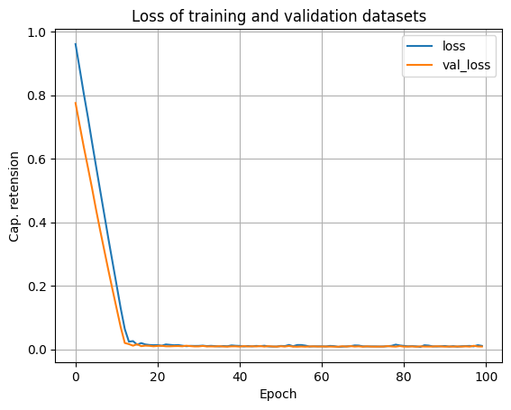

```python
hist = pd.DataFrame(history.history)
hist['epoch'] = history.epoch

def plot_loss(history):
    plt.plot(history.history['loss'], label='loss')
    plt.plot(history.history['val_loss'], label='val_loss')
    plt.xlabel('Epoch')
    plt.ylabel('Cap. retension')
    plt.legend()
    plt.grid(True)
    plt.title('Loss of training and validation datasets')
plot_loss(history)
```

```python
test_results = {}

test_results['linear_model'] = linear_model.evaluate(test_features, test_labels)
```

```python
test_results
```

```
{'linear_model': 0.020403238013386726}
```

```python
test_labels[0:1]
```

|  | Cap_retention |
| --- | --- |
| 106 | 0.924774 |

```python
linear_model.predict(test_features[0:1])
```

```
array([[0.93518853]], dtype=float32)
```

```
[0.93518853 0.93345743 0.9353479  0.93571234 0.9351162  0.93468064
 0.93693304 0.93536174 0.934299   0.93730175 0.93426895 0.93166244
 0.9334172  0.93384963 0.9368563  0.9341507  0.9335197  0.9359204
 0.65846604 0.9320125  0.9327207  0.9351929  0.93552536 0.9333121
 0.9356105  0.935041   0.93401253 0.9361842  0.9336246  0.93282896
 0.9334561  0.9363537  0.9371927  0.9362437  0.93622863 0.93701404
 0.9342227  0.9337846  0.9334619  0.9350292  0.93433595 0.935823
 0.932614   0.9347445  0.93655306 0.93665797 0.9319494  0.93328834
 0.9344626  0.9349158  0.9328428  0.9346716  0.9344144  0.93562526
 0.93625736 0.9357346  0.9353207  0.9342359  0.9356215  0.9375454
 0.93559766 0.9330607  0.9377341  0.93532354 0.9356164  0.9343173
 0.9359117  0.9336048  0.9326871  0.93572    0.6722496  0.9344815
 0.93457407]
     Cap_retention
106       0.924774
262       0.935543
45        0.928261
26        0.943460
78        0.947573
..             ...
220       0.945087
160       0.946002
74        0.267013
171       0.952287
114       0.926345

[73 rows x 1 columns]
```

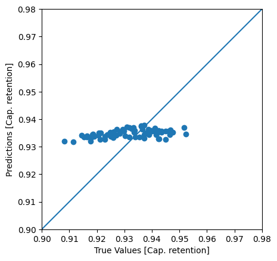

```python
test_predictions = linear_model.predict(test_features).flatten()
print(test_predictions)
print(test_labels)
def plot_err(test_labels,test_predictions):
    a = plt.axes(aspect='equal')
    plt.scatter(test_labels, test_predictions)
    plt.xlabel('True Values [Cap. retention]')
    plt.ylabel('Predictions [Cap. retention]')
    lims = [0.9, 0.98]
    plt.xlim(lims)
    plt.ylim(lims)
    _ = plt.plot(lims, lims)
plot_err(test_labels,test_predictions)
```

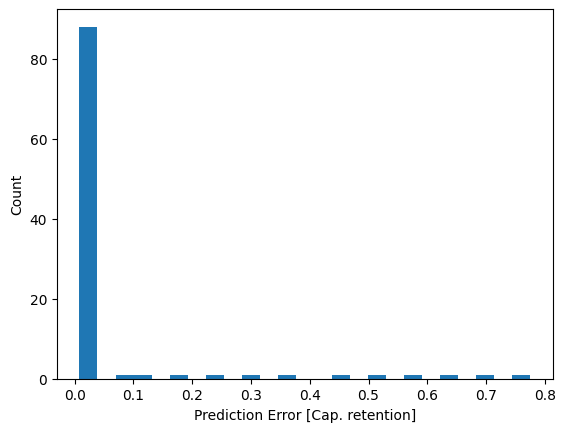

```python
error = history.history['val_loss']
plt.hist(error, bins=25)
plt.xlabel('Prediction Error [Cap. retention]')
_ = plt.ylabel('Count')
```

```python
tf_train(X_new_one, y_new_one, clf,standardize = True)
```

```
(292, 4) (292, 1)
Using Normalized data
Mean squared error  21.666438846199082
r2 score  -1600.7242456233232
```

```
array([  1.5893304,   1.4809682,   1.3511813,   1.2703431,   1.332761 ,
         1.458071 ,   1.6359656,   1.3496668,   1.4166682,   1.3061583,
         1.6300495,   1.6927972,   1.5648146,   1.6502798,   1.308687 ,
         1.6440763,   1.5860374,   1.4708145, -28.263922 ,   1.6831822,
         1.6044693,   1.5850809,   1.4712341,   1.509927 ,   1.2379196,
         1.6798527,   1.3174121,   1.5509632,   1.44641  ,   1.4641373,
         1.7189019,   1.6157234,   1.3663833,   1.39131  ,   1.5147235,
         1.2598279,   1.3107064,   1.6347802,   1.4998543,   1.4125507,
         1.638058 ,   1.2320821,   1.5471752,   1.6333497,   1.337158 ,
         1.4043167,   1.558923 ,   1.6211083,   1.4569037,   1.4251707,
         1.4741914,   1.5238521,   1.3678386,   1.6179335,   1.5795295,
         1.4740584,   1.3920453,   1.598145 ,   1.4523752,   1.613189 ,
         1.4861934,   1.5203724,   1.3390105,   1.4786355,   1.485678 ,
         1.4077947,   1.4757016,   1.692817 ,   1.5813243,   1.5771105,
       -27.098623 ,   1.5492551,   1.5964956], dtype=float32)
```

## Explore tpot to search which regressor is the best

```python
%%time
from tpot import TPOTRegressor
tpot = TPOTRegressor(generations=4, # set to 4 to run faster for testing
                     population_size=40,

                     verbosity=2,
                     random_state=42)
tpot.fit(train_features, train_labels)
```

```
Generation 1 - Current best internal CV score: -5.2456329057359486e-05

Generation 2 - Current best internal CV score: -5.2456329057359486e-05

Generation 3 - Current best internal CV score: -5.2029186352093085e-05

Generation 4 - Current best internal CV score: -5.089168529401108e-05

Best pipeline: RandomForestRegressor(LassoLarsCV(input_matrix, normalize=False), bootstrap=True, max_features=0.7500000000000001, min_samples_leaf=11, min_samples_split=9, n_estimators=100)
CPU times: user 2min 39s, sys: 6.54 s, total: 2min 46s
Wall time: 1min 47s
```

```
TPOTRegressor(generations=4, population_size=40, random_state=42, verbosity=2)
```

## Use Randomforest regressor for the training

```python
from sklearn.ensemble import RandomForestRegressor
from sklearn.linear_model import LassoLarsCV
import joblib
from pathlib import Path
#BASE_DIR = Path(__file__).resolve(strict=True).parent
BASE_DIR = '/Users/michael/Documents/Projects/NewareDataProcessing'
# Instantiate and fit the model
rfc = RandomForestRegressor(bootstrap=True, max_features=0.7500000000000001, min_samples_leaf=11, min_samples_split=9, n_estimators=100)
model = rfc.fit(train_features, train_labels)

# Use the model to predict diabetes type
rfc_predictions = model.predict(test_features)

joblib.dump(model, Path(BASE_DIR).joinpath(f"{'RFR'}.joblib"))
```

```
['/Users/michael/Documents/Projects/NewareDataProcessing/RFR.joblib']
```

```
R-squared: -2.1794558040090903
MSE:  0.37744250079647074
RMSE:  0.18872125039823537
```

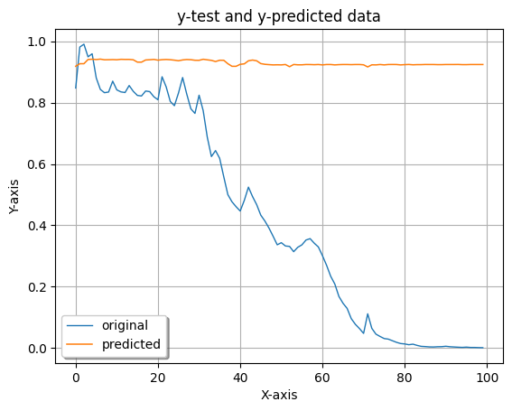

```python
# quick test with other cells data
six = pd.read_csv("ProcessedData/OneHundred/Final.csv")
six.dropna(inplace=True)
X_new_ot = six[['Voltage(V)', 'Voltage(V)-d','Voltage(V)-max', 'Voltage(V)-min']]
y_new_ot= six[['Cap_retention']]
y_new_ot.replace(to_replace = 0, value = 1, inplace=True)

y_pred = model.predict(X_new_ot)

mse = mean_squared_error(y_new_ot, y_pred)
score = model.score(X_new_ot, y_new_ot)
print("R-squared:", score)
print("MSE: ", mse)
print("RMSE: ", mse*(1/2.0))
x_ax = range(len(y_new_ot))
plt.plot(x_ax, y_new_ot, linewidth=1, label="original")
plt.plot(x_ax, y_pred, linewidth=1.1, label="predicted")
plt.title("y-test and y-predicted data")
plt.xlabel('X-axis')
plt.ylabel('Y-axis')
plt.legend(loc='best',fancybox=True, shadow=True)
plt.grid(True)
plt.show()
```

```python
six.head(6)
```

|  | Unnamed: 0 | Voltage(V) | Voltage(V)-d | Cycle ID | Cap_Chg(mAh) | Cap_DChg(mAh) | Chg/DChg Efficiency(%) | Cap_retention | Voltage(V)-max | Voltage(V)-min |
| --- | --- | --- | --- | --- | --- | --- | --- | --- | --- | --- |
| 0 | 0 | 3.4139 | 3.4933 | 1 | 3.5000 | 2.9844 | 85.267 | 0.852686 | 4.0516 | 3.0000 |
| 1 | 1 | 4.0448 | 3.5091 | 2 | 3.5001 | 3.4149 | 97.565 | 0.975686 | 4.1979 | 2.9997 |
| 2 | 2 | 4.1861 | 3.5063 | 3 | 3.5001 | 3.5149 | 100.424 | 1.004257 | 4.2184 | 2.9997 |
| 3 | 3 | 4.2069 | 3.5292 | 4 | 3.5000 | 3.3471 | 95.631 | 0.956314 | 4.2196 | 3.0000 |
| 4 | 4 | 4.2007 | 3.5224 | 5 | 3.5001 | 3.5461 | 101.315 | 1.013171 | 4.2748 | 2.9991 |
| 5 | 5 | 4.2513 | 3.4936 | 6 | 3.5001 | 0.0000 | 0.000 | 0.000000 | 4.2494 | 3.5931 |

```python
from sklearn.metrics import mean_squared_error

mse = mean_squared_error(test_labels, rfc_predictions)
score = model.score(train_features, train_labels)
print("R-squared:", score)
print("MSE: ", mse)
print("RMSE: ", mse*(1/2.0))
```

```
R-squared: 0.655229440029654
MSE:  0.013747138922283401
RMSE:  0.006873569461141701
```

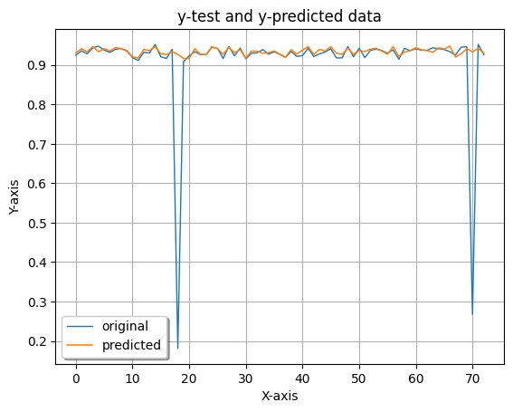

```python
x_ax = range(len(test_labels))
plt.plot(x_ax, test_labels, linewidth=1, label="original")
plt.plot(x_ax, rfc_predictions, linewidth=1.1, label="predicted")
plt.title("y-test and y-predicted data")
plt.xlabel('X-axis')
plt.ylabel('Y-axis')
plt.legend(loc='best',fancybox=True, shadow=True)
plt.grid(True)
plt.show()
```

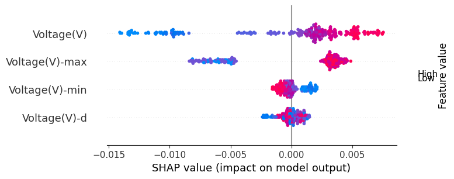

```python
import shap

explainer = shap.TreeExplainer(model)
shap_val = explainer.shap_values(train_features)
# #shap.summary_plot(shap_val, XN.values,plot_type='bar')
#shap.plots.beeswarm(shap_val, max_display=20)
shap.summary_plot(shap_val, train_features)
```

```python
from sklearn.tree import export_graphviz
estimator = model.estimators_[5]
# Export as dot file
export_graphviz(estimator, out_file='tree.dot',
                feature_names = train_features.columns,
                class_names = train_labels.columns,
                rounded = True, proportion = False,
                precision = 2, filled = True)
```

```python
# Convert to png using system command (requires Graphviz)
from subprocess import call
call(['dot', '-Tpng', 'tree.dot', '-o', 'tree.png', '-Gdpi=600'])

# Display in jupyter notebook
from IPython.display import Image
Image(filename = 'tree.png')
```

[figure not shown]

```python
c = df_final.columns.to_list()
print(c)
```

```python
df_final[['Cycle ID1', 'Cap_Chg(mAh)1', 'Cap_DChg(mAh)1', 'Chg/DChg Efficiency(%)1']]
```

```python
#df_final.reset_index(inplace=True)
#df_final.rename(columns={'CellID':'CellID'})
```

```python
#x = df_final.pivot(columns='CellID')
```

```python
#x.shape
```

```python
df_train = df_final.copy()
df_train.drop(columns=drop_cycid,inplace=True)
df_train.fillna(0, inplace=True)
```

```python
df_train.head()
```

## Explore correlation of data, remove high correlated data

```python
cor = df_train.corr()
keep_columns = np.full(cor.shape[0], True)
for i in range(cor.shape[0] - 1):
    for j in range(i + 1, cor.shape[0] - 1):
        if (np.abs(cor.iloc[i, j]) >= 0.9): # 0.8 is the correlation threshold
            keep_columns[j] = False
selected_columns = df_train.columns[keep_columns]
X_train_reduced = df_train[selected_columns]
```

```python
X_train_reduced.shape
```

```python
X_train_reduced.columns
```

```python
X_train_reduced.tail()
```

## Explore clustering for the data

```python
#clustering the data
from sklearn.preprocessing import StandardScaler

import numpy as np
import pandas as pd
import matplotlib.pyplot as plt
import seaborn as sns
%matplotlib inline

import os
import warnings

warnings.filterwarnings('ignore')
from matplotlib import style
style.use('dark_background')
```

```python
from sklearn.cluster import KMeans
X = X_train_reduced
clusters = []

for i in range(1, 5):
    km =  KMeans(n_clusters=i).fit(X)
    clusters.append(km.inertia_)

fig, ax = plt.subplots(figsize=(12, 8))
sns.lineplot(x=list(range(1, 5)), y=clusters, ax=ax)
ax.set_title('Searching for Elbow')
ax.set_xlabel('Clusters')
ax.set_ylabel('Inertia')
```

```python
km3 = KMeans(n_clusters = 3).fit(X)

X['Labels'] = km3.labels_
plt.figure(figsize=(12, 8))
sns.scatterplot(X['OCV_charge1'], X['Cap_Chg(mAh)3'], hue=X['Labels'],
                palette=sns.color_palette('hls', 3))
plt.title('KMeans with 3 Clusters')
plt.show()
```

```python
X.head()
```

```python
t = X.copy()
t.reset_index(inplace=True)

t.rename(columns={'CellID':'CellID'})
```

```python
plt.figure(figsize=(12, 8))
sns.scatterplot( t['OCV_charge1'],t['Cap_Chg(mAh)3'], hue=t['Labels'],
                palette=sns.color_palette('hls', 3))
plt.title('KMeans with 3 Clusters')
plt.show()
```

```python
t['Voltage_min1']
```

```python
t[['CellID','Labels']].sort_values(by='Labels')
```

```python
from sklearn.decomposition import PCA
n=df_train.shape[0]

#Finding principal components for the data
pca =PCA(n_components=n, random_state=1)# Applying the PCA algorithm with random state = 1
data_pca1 = pd.DataFrame(pca.fit_transform(df_train)) #Fitting and transforming the pca function on scaled data

#The percentage of variance explained by each principal component
exp_var = pca.explained_variance_ratio_

plt.figure(figsize = (10,10))
plt.plot(range(1,24), exp_var.cumsum(), marker = 'o', linestyle = '--')
plt.title("Explained Variances by Components")
plt.xlabel("Number of Components")
plt.ylabel("Cumulative Explained Variance")
```

```python
# finding the least number of components that can explain more than 90% variance
sum = 0
for ix, i in enumerate(exp_var):
  sum = sum + i
  if(sum>0.90):
    print("Number of PCs that explain at least 90% variance: ", ix+1)
    break
```

```python
pc_comps = ['PC1','PC2','PC3']
data_pca = pd.DataFrame(np.round(pca.components_[:3,:],2),index=pc_comps,columns=df_train.columns)
data_pca.T
```

```python
df_concat = pd.concat([data_pca1, X], axis=1)

plt.figure(figsize = (7,7))
#Create a scatter plot with x=0 and y=1 using df_concat dataframe
sns.scatterplot(x = 0, y = 1, data=df_concat, hue = 'OCV_charge1')

plt.xlabel("PC1")
plt.ylabel("PC2")
```

```python
df_concat.head()
```